# ActurialSciences_project

Najad Feimi

2023-01-14

## Introduction

The data that I am working with is Auto Insurance Claims. It is a dataset of 40 columns where information about the insured person is gathered. This dataset is created to predict the Insurance Fraud which is a huge problem in the industry, but I am going to use it to predict the total claim. Most of the columns in the dataset, which I presented as a dataframe below are comprehensive but I would like to pay a bit attention to some field terms which may not be comprehensive by everyone.

Some of these terms are: 1. Policy CSL, 2. Policy Deductable, Policy Annual Premium, umbrella limit, Total Claim Amount.

These terms also are some of the most important in the dataframe, therefore it would be beneficial to explain them.

1. Combined single limit (CSL) is a type of liability insurance coverage that combines the limits for two or more types of liability coverage into one overall limit. The limit applies to the total amount of damages for all claims combined, rather than having separate limits for each type of coverage.

The numbers in the format shown before of CSL limit typically refers to two separate liability limits: The first number in the limit is the limit for bodily injury liability and the second number is the limit for property damage liability.

2. Policy Deductable is a set amount that the policyholder must pay out of pocket before their insurance coverage begins to pay for covered losses. The policy deductible applies to each covered claim, and the amount of the deductible can vary depending on the type of policy and the specific coverage.
3. An annual premium is the amount of money that an individual or organization is required to pay for an insurance policy on an annual basis. The annual premium is determined by a variety of factors, including the type of coverage, the amount of coverage, the level of risk, and the insurance company’s underwriting practices.
4. An umbrella limit is a type of insurance coverage that provides an additional layer of protection beyond the limits of a primary policy.
5. Total claim amount which also is going to serve as my target variable is the summation of injury claim, property claim and vehicle claim. A claim amount refers to the amount of money that an individual or organization is seeking to recover from an insurance policy as a result of a covered loss.

I am going to use the variables to predict this amount.

```r
Auto_claims <- read.csv("/home/najada/Documents/MADS/Semester 3/Acturial_sciences/archive (2)/insurance_claims.csv", sep = ",")
head(Auto_claims )
```

```
##   months_as_customer age policy_number policy_bind_date policy_state policy_csl
## 1                328  48        521585       2014-10-17           OH    250/500
## 2                228  42        342868       2006-06-27           IN    250/500
## 3                134  29        687698       2000-09-06           OH    100/300
## 4                256  41        227811       1990-05-25           IL    250/500
## 5                228  44        367455       2014-06-06           IL   500/1000
## 6                256  39        104594       2006-10-12           OH    250/500
##   policy_deductable policy_annual_premium umbrella_limit insured_zip
## 1              1000               1406.91              0      466132
## 2              2000               1197.22        5000000      468176
## 3              2000               1413.14        5000000      430632
## 4              2000               1415.74        6000000      608117
## 5              1000               1583.91        6000000      610706
## 6              1000               1351.10              0      478456
##   insured_sex insured_education_level insured_occupation insured_hobbies
```

[output cut: 55 more lines]

## Preliminary analysis of the data

Let’s focus to understand the data as good as we can and do the necessary transformations in order to make a model as accurate as possible.

First thing first we check for duplicates. The identifying column in the dataframe is policy_number therefore we use this column to check for duplicates.

```
## [1] 0
```

Now we start exploring the data to undersand what we have to do.

Firstly checking the data types of each column.

```r
str(Auto_claims)
```

```
## 'data.frame':    1000 obs. of  40 variables:
##  $ months_as_customer         : int  328 228 134 256 228 256 137 165 27 212 ...
##  $ age                        : int  48 42 29 41 44 39 34 37 33 42 ...
##  $ policy_number              : int  521585 342868 687698 227811 367455 104594 413978 429027 485665 636550 ...
##  $ policy_bind_date           : chr  "2014-10-17" "2006-06-27" "2000-09-06" "1990-05-25" ...
##  $ policy_state               : chr  "OH" "IN" "OH" "IL" ...
##  $ policy_csl                 : chr  "250/500" "250/500" "100/300" "250/500" ...
##  $ policy_deductable          : int  1000 2000 2000 2000 1000 1000 1000 1000 500 500 ...
##  $ policy_annual_premium      : num  1407 1197 1413 1416 1584 ...
##  $ umbrella_limit             : int  0 5000000 5000000 6000000 6000000 0 0 0 0 0 ...
##  $ insured_zip                : int  466132 468176 430632 608117 610706 478456 441716 603195 601734 600983 ...
##  $ insured_sex                : chr  "MALE" "MALE" "FEMALE" "FEMALE" ...
##  $ insured_education_level    : chr  "MD" "MD" "PhD" "PhD" ...
##  $ insured_occupation         : chr  "craft-repair" "machine-op-inspct" "sales" "armed-forces" ...
##  $ insured_hobbies            : chr  "sleeping" "reading" "board-games" "board-games" ...
```

[output cut: 26 more lines]

At the display of the dataset we see a lot of values that are written as “?”. We replace the question mark with NA in order to deal with them as nan values.

```r
Auto_claims[Auto_claims == "?"] <- NA
```

We check and the output and the values have been replaced as needed.

```r
str(Auto_claims)
```

```
## 'data.frame':    1000 obs. of  40 variables:
##  $ months_as_customer         : int  328 228 134 256 228 256 137 165 27 212 ...
##  $ age                        : int  48 42 29 41 44 39 34 37 33 42 ...
##  $ policy_number              : int  521585 342868 687698 227811 367455 104594 413978 429027 485665 636550 ...
##  $ policy_bind_date           : chr  "2014-10-17" "2006-06-27" "2000-09-06" "1990-05-25" ...
##  $ policy_state               : chr  "OH" "IN" "OH" "IL" ...
##  $ policy_csl                 : chr  "250/500" "250/500" "100/300" "250/500" ...
##  $ policy_deductable          : int  1000 2000 2000 2000 1000 1000 1000 1000 500 500 ...
##  $ policy_annual_premium      : num  1407 1197 1413 1416 1584 ...
##  $ umbrella_limit             : int  0 5000000 5000000 6000000 6000000 0 0 0 0 0 ...
##  $ insured_zip                : int  466132 468176 430632 608117 610706 478456 441716 603195 601734 600983 ...
##  $ insured_sex                : chr  "MALE" "MALE" "FEMALE" "FEMALE" ...
##  $ insured_education_level    : chr  "MD" "MD" "PhD" "PhD" ...
##  $ insured_occupation         : chr  "craft-repair" "machine-op-inspct" "sales" "armed-forces" ...
##  $ insured_hobbies            : chr  "sleeping" "reading" "board-games" "board-games" ...
```

[output cut: 26 more lines]

Now we need to deal with these missing values so let’s start working on them.

First I cound them.

```r
sum(is.na(Auto_claims))
```

```
## [1] 1881
```

Then I check the missing values for each column.

```r
apply(is.na(Auto_claims), 2, sum)
```

```
##          months_as_customer                         age
##                           0                           0
##               policy_number            policy_bind_date
##                           0                           0
##                policy_state                  policy_csl
##                           0                           0
##           policy_deductable       policy_annual_premium
##                           0                           0
##              umbrella_limit                 insured_zip
##                           0                           0
##                 insured_sex     insured_education_level
##                           0                           0
##          insured_occupation             insured_hobbies
##                           0                           0
##        insured_relationship               capital.gains
##                           0                           0
##                capital.loss               incident_date
##                           0                           0
##               incident_type              collision_type
##                           0                         178
##           incident_severity       authorities_contacted
##                           0                           0
##              incident_state               incident_city
##                           0                           0
##           incident_location    incident_hour_of_the_day
##                           0                           0
## number_of_vehicles_involved             property_damage
##                           0                         360
##             bodily_injuries                   witnesses
##                           0                           0
##     police_report_available          total_claim_amount
##                         343                           0
##                injury_claim              property_claim
##                           0                           0
##               vehicle_claim                   auto_make
##                           0                           0
##                  auto_model                   auto_year
##                           0                           0
##              fraud_reported                       X_c39
##                           0                        1000
```

For the last column we can see that it has 1000 NA values, the dataframe has also 1000 rows which means that all the values from this column are NA, therefore this column is all empty and we do not need it. I’ve decided to delete this column.

```r
Auto_claims <- subset(Auto_claims, select = -X_c39)
```

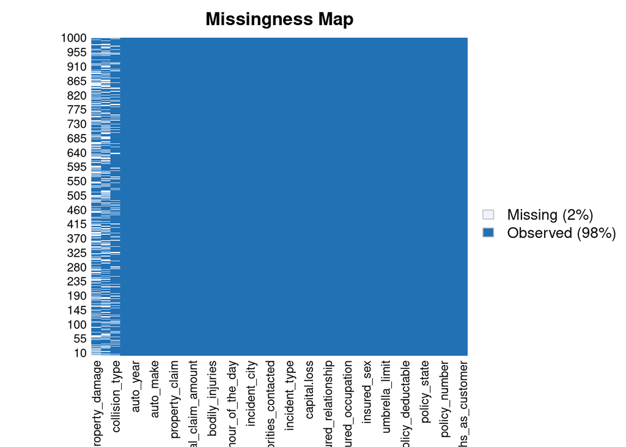

```r
library(Amelia)
missmap(Auto_claims)
```

According to the output of the code and the plot there are 3 columns with missing values: “police_report_available”, “collision_type” and “property_damage”.

Checking each column, what it represents, its type and values we can decide on how we want to deal with these values.

```r
unique(Auto_claims$police_report_available)
```

```
## [1] "YES" NA    "NO"
```

```r
unique(Auto_claims$property_damage)
```

```
## [1] "YES" NA    "NO"
```

```r
unique(Auto_claims$collision_type)
```

```
## [1] "Side Collision"  NA                "Rear Collision"  "Front Collision"
```

```r
unique(Auto_claims$auto_year)
```

```
##  [1] 2004 2007 2014 2009 2003 2012 2015 1996 2002 2006 2000 2010 1999 2011 2005
## [16] 2008 1995 2001 1998 1997 2013
```

Now we can see what distinct values we have for every column with missing values in order to choose correctly the value we will use to impute.

Lastly, there is **the collision type**. Here the reasoning is quite difficult because at the first sight we have no idea what the collision might have been. Therefore the first idea coming to mind is to fill it with the mode, the most common value of the column. But I chose to go down the hard road. My idea was to inspect two columns: Collision type and incident type which seems to be related because one describes the type of incident and the other more specifically, the type of collisions which is a subgroup of incidents.